# ABM_orchest_v1

2026-04-02

`{r-setup, include=FALSE} knitr::opts_chunk$set(echo = TRUE, warning = FALSE, message = FALSE, fig.width = 15, fig.height = 10)`

# Preface

- this document considers one version of LHS and one of GA (100 fixed cycles) – the other with dynamic convergence (convergence_threshold at 0.01) which is designated as **v2**
- Further all of the data displayed below is only considering M (mixed) debates which constitute a mix of pro and anti reduction agents (a future version to be run next week - form 25/5/26 onwards will introduce better segmentation and cross comparison of H and M debates)
- All analyses where data is not labelled in **v1** or **v2** is run with **v1** (which biases the interpretation as each debate is forced to run until it reaches 100 cycles)
- use_distinct_agents: **TRUE** (each agent has the same base parameter value but has a standard deviation associated with each parameter) / **FALSE** (all agents in that debate have the same parameter value -> assumes agents are all the same)

# Empirical data discovery

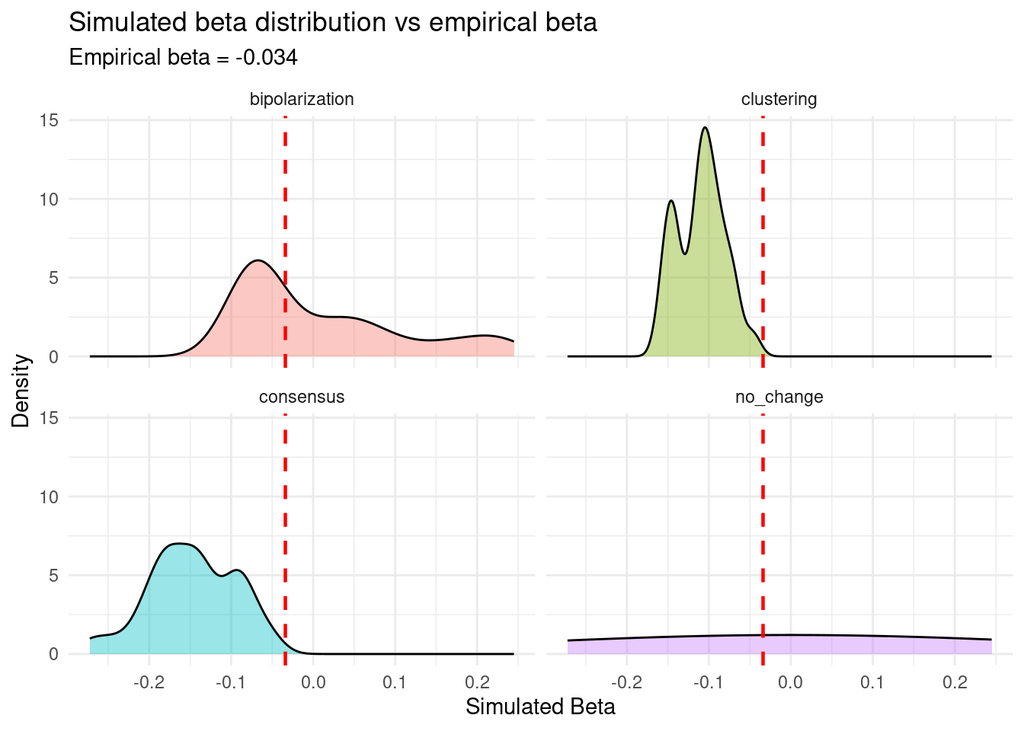

```r
# Beta Distribution Check
lhs_outputs$plots$beta_distance_vs_empir()
```

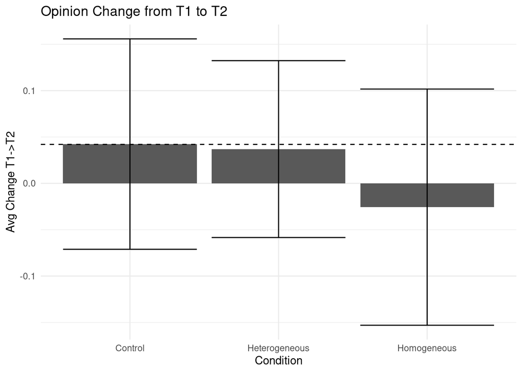

```r
# Empirical Outcome Distributions
lhs_outputs$plots$empirical_col()
```

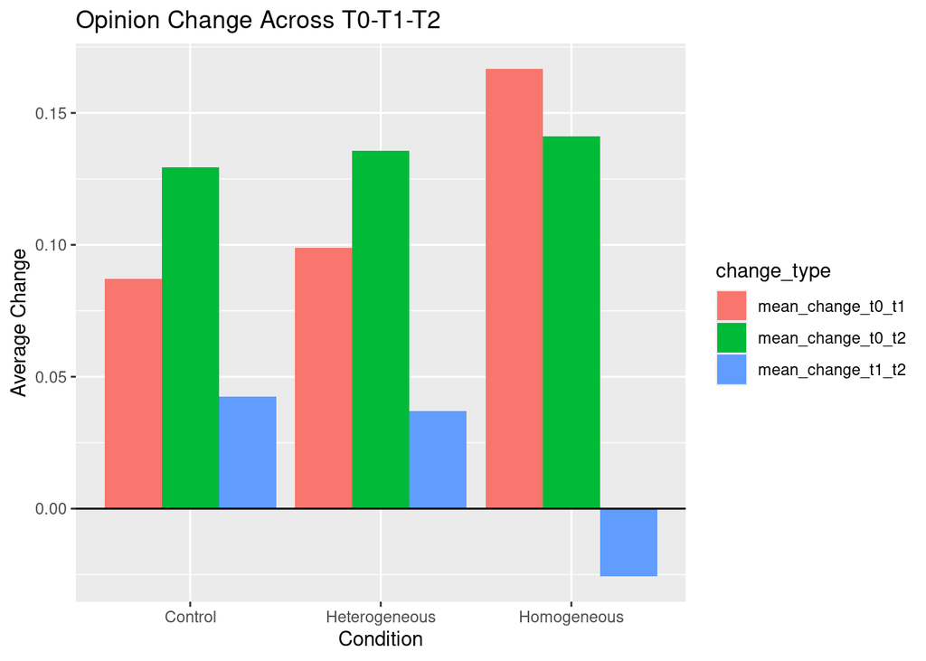

```r
lhs_outputs$plots$empirical_cross()
```